# DS202_Lab2

*Beans originating from Brazil tend to produce creamier chocolate while those from Colombia produce sweeter chocolate. Beans from Brazil tend to produce chocolate that has better characteristics and less negative ones such as gritty, dry etc… The mean rating for Brazil is 3.263 which is higher than the other countries in the last list*

```r
library(tidyverse)
flavor <- table(choco$Characteristics1)
length(flavor)
```

```
## [1] 499
```

```r
summary(as.numeric(flavor))
```

```
##    Min. 1st Qu.  Median    Mean 3rd Qu.    Max.
##   1.000   1.000   1.000   4.914   3.000 162.000
```

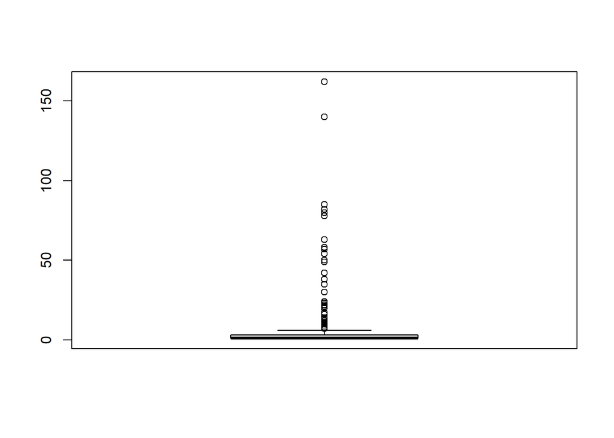

```r
boxplot(flavor)
```

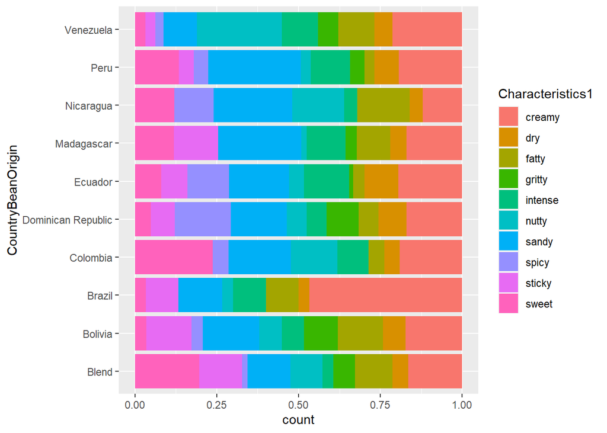

```r
flavor_filtered <- flavor[flavor > 50]
choco_filtered <- filter(choco, Characteristics1 %in% names(flavor_filtered))

country_filtered <- table(choco$CountryBeanOrigin) %>%
  sort(decreasing = TRUE) %>%
  head(10) # select the top 10 countries

choco %>%
  filter(Characteristics1 %in% names(flavor_filtered)) %>% # filter flavor
  filter(CountryBeanOrigin %in% names(country_filtered)) %>% # filter country
  ggplot() +
  geom_bar(aes(x = CountryBeanOrigin, fill = Characteristics1), position = 'fill') + # position = 'fill': especially used when showing proportions (all columns add up to 1)
  coord_flip() # rotate the coordinate
```

```r
tapply(choco$Rating, choco$CountryBeanOrigin, summary) %>%
  head(5) # Country list might be too long to show, we keep it to 5
```

```
## $Australia
##    Min. 1st Qu.  Median    Mean 3rd Qu.    Max.
##    2.75    3.00    3.25    3.25    3.50    3.75
##
## $Belize
##    Min. 1st Qu.  Median    Mean 3rd Qu.    Max.
##   2.500   3.000   3.250   3.236   3.500   4.000
##
## $Blend
##    Min. 1st Qu.  Median    Mean 3rd Qu.    Max.
##   1.000   2.750   3.000   3.037   3.500   4.000
##
## $Bolivia
##    Min. 1st Qu.  Median    Mean 3rd Qu.    Max.
##   2.000   3.000   3.250   3.175   3.500   4.000
##
## $Brazil
##    Min. 1st Qu.  Median    Mean 3rd Qu.    Max.
##   1.750   3.000   3.250   3.263   3.500   4.000
```

**5**

*I want to use the previous analysis we did above but using the other 2 Characteristics of a chocolate to see which country of origin contains the most favorable characteristics.Based on my findings, If chocolate companies want a nutty profile chocolate bar, they should use beans from Colombia. If they want a rich flavor of Cacao, they should use a blend of bean origins.If they want a floral profile, they should go with beans sourced in Ecuador. Across all three analysis, Brazil has the most favorable traits/profile for chocolate . Other useful analysis would include a comparison of what countries source their cocoa beans from and then compare the average rating per company to determine who produces the best chocolate.*

```r
flavor2 <- table(choco$Characteristics2)
length(flavor2)
```

```
## [1] 528
```

```r
summary(as.numeric(flavor2))
```

```
##    Min. 1st Qu.  Median    Mean 3rd Qu.    Max.
##   1.000   1.000   1.000   4.517   3.000 124.000
```

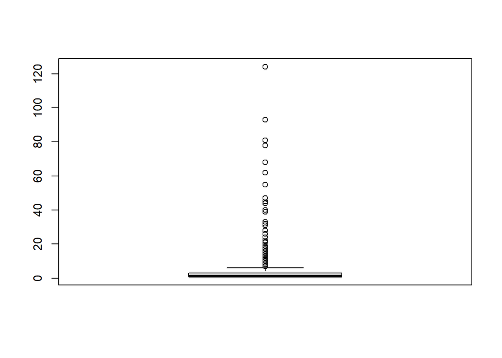

```r
boxplot(flavor2)
```

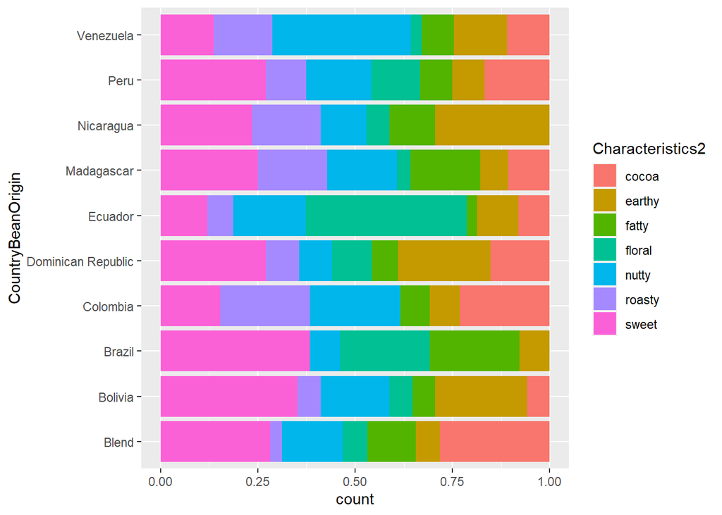

```r
flavor_filtered2 <- flavor2[flavor2 > 50]
choco_filtered2 <- filter(choco, choco$Characteristics2 %in% names(flavor_filtered2))

country_filtered2 <- table(choco$CountryBeanOrigin) %>%
  sort(decreasing = TRUE) %>%
  head(10) # select the top 10 countries

choco %>%
  filter(Characteristics2 %in% names(flavor_filtered2)) %>% # filter flavor
  filter(CountryBeanOrigin %in% names(country_filtered2)) %>% # filter country
  ggplot() +
  geom_bar(aes(x = CountryBeanOrigin, fill = Characteristics2), position = 'fill') + # position = 'fill': especially used when showing proportions (all columns add up to 1)
  coord_flip() # rotate the coordinate
```

```r
tapply(choco$Rating, choco$CountryBeanOrigin, summary) %>%
  head(5) # Country list might be too long to show, we keep it to 5
```

```
## $Australia
##    Min. 1st Qu.  Median    Mean 3rd Qu.    Max.
##    2.75    3.00    3.25    3.25    3.50    3.75
##
## $Belize
##    Min. 1st Qu.  Median    Mean 3rd Qu.    Max.
##   2.500   3.000   3.250   3.236   3.500   4.000
##
## $Blend
##    Min. 1st Qu.  Median    Mean 3rd Qu.    Max.
##   1.000   2.750   3.000   3.037   3.500   4.000
##
## $Bolivia
##    Min. 1st Qu.  Median    Mean 3rd Qu.    Max.
##   2.000   3.000   3.250   3.175   3.500   4.000
##
## $Brazil
##    Min. 1st Qu.  Median    Mean 3rd Qu.    Max.
##   1.750   3.000   3.250   3.263   3.500   4.000
```

```r
flavor3 <- table(choco$Characteristics3)
length(flavor3)
```

```
## [1] 356
```

```r
summary(as.numeric(flavor3))
```

```
##    Min. 1st Qu.  Median    Mean 3rd Qu.    Max.
##   1.000   1.000   1.000   4.955   4.000 110.000
```

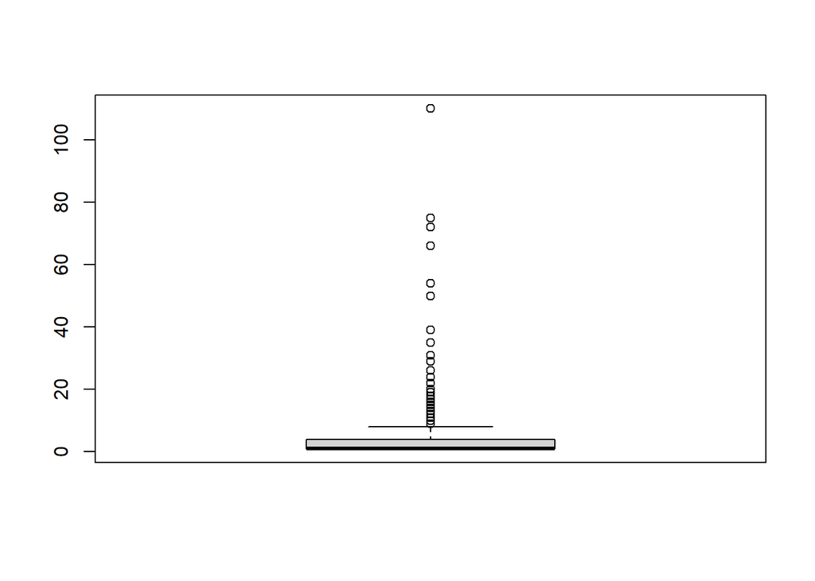

```r
boxplot(flavor3)
```

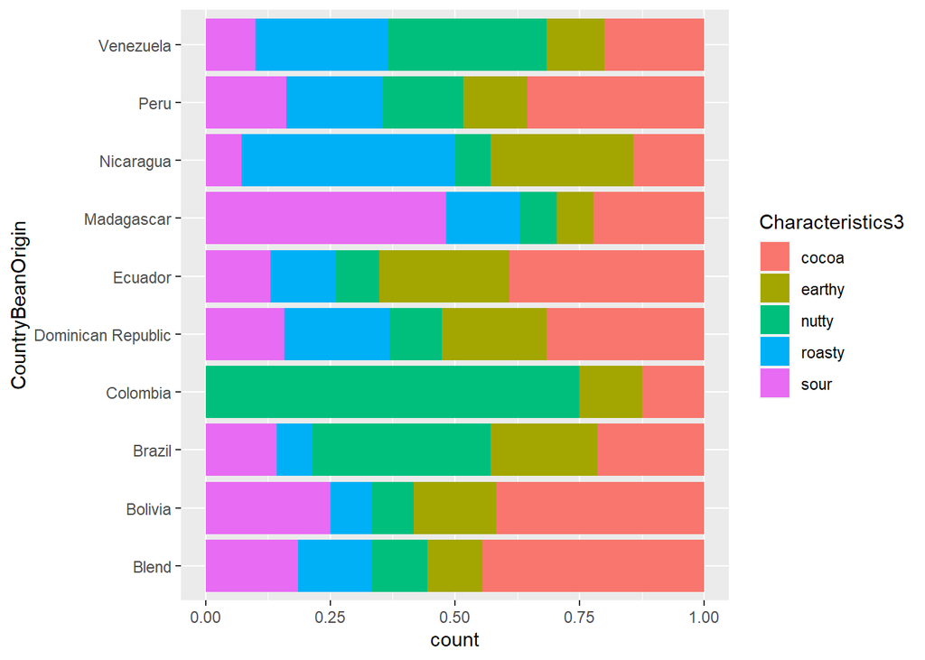

```r
flavor_filtered3 <- flavor3[flavor3 > 50]
choco_filtered3 <- filter(choco, choco$Characteristics3 %in% names(flavor_filtered3))

country_filtered3 <- table(choco$CountryBeanOrigin) %>%
  sort(decreasing = TRUE) %>%
  head(10) # select the top 10 countries

choco %>%
  filter(Characteristics3 %in% names(flavor_filtered3)) %>% # filter flavor
  filter(CountryBeanOrigin %in% names(country_filtered3)) %>% # filter country
  ggplot() +
  geom_bar(aes(x = CountryBeanOrigin, fill = Characteristics3), position = 'fill') + # position = 'fill': especially used when showing proportions (all columns add up to 1)
  coord_flip() # rotate the coordinate
```

```r
tapply(choco$Rating, choco$CountryBeanOrigin, summary) %>%
  head(5) # Country list might be too long to show, we keep it to 5
```

```
## $Australia
##    Min. 1st Qu.  Median    Mean 3rd Qu.    Max.
##    2.75    3.00    3.25    3.25    3.50    3.75
##
## $Belize
##    Min. 1st Qu.  Median    Mean 3rd Qu.    Max.
##   2.500   3.000   3.250   3.236   3.500   4.000
##
## $Blend
##    Min. 1st Qu.  Median    Mean 3rd Qu.    Max.
##   1.000   2.750   3.000   3.037   3.500   4.000
##
## $Bolivia
##    Min. 1st Qu.  Median    Mean 3rd Qu.    Max.
##   2.000   3.000   3.250   3.175   3.500   4.000
##
## $Brazil
##    Min. 1st Qu.  Median    Mean 3rd Qu.    Max.
##   1.750   3.000   3.250   3.263   3.500   4.000
```